# Exercise 3.2.1 - PCA by Ardiansyah (177867)

# Step 1. Generating 3-dimensional sample data

400 3-Dimensional samples stem from two different classes, where one half (i.e., 200) samples of our data set are labeled ω1 (class 1) and the other half ω2 (class 2).

```python
import numpy as np

np.random.seed(0)

mu_vec1 = np.array([-6,6,6]) #mean m1
cov_mat1 = np.array([[0.3,1.0,1.0],[1.0,9.0,1.0],[1.0,1.0,9.0]]) #covariance matrix
class1_sample = np.random.multivariate_normal(mu_vec1, cov_mat1, 200).T
assert class1_sample.shape == (3,200)

mu_vec2 = np.array([6,6,6]) #mean m2
cov_mat2 = np.array([[0.3,1.0,1.0],[1.0,9.0,1.0],[1.0,1.0,9.0]]) #covariance matrix
class2_sample = np.random.multivariate_normal(mu_vec2, cov_mat2, 200).T
assert class2_sample.shape == (3,200)
```

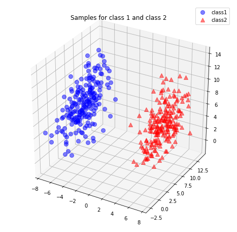

```python
%pylab inline
from matplotlib import pyplot as plt
from mpl_toolkits.mplot3d import Axes3D
from mpl_toolkits.mplot3d import proj3d

fig = plt.figure(figsize=(8,8))
ax = fig.add_subplot(111, projection='3d')
plt.rcParams['legend.fontsize'] = 10
ax.plot(class1_sample[0,:], class1_sample[1,:], class1_sample[2,:], 'o', markersize=8, color='blue', alpha=0.5, label='class1')
ax.plot(class2_sample[0,:], class2_sample[1,:], class2_sample[2,:], '^', markersize=8, alpha=0.5, color='red', label='class2')

plt.title('Samples for class 1 and class 2')
ax.legend(loc='upper right')

plt.show()
```

# Step 2. Taking the whole dataset ignoring the class labels

Because we don’t need class labels for the PCA analysis, let us merge the samples for our 2 classes into one 3×400-dimensional array

```python
all_samples = np.concatenate((class1_sample, class2_sample), axis=1)
assert all_samples.shape == (3,400)
```

# Step 3. Computing the d-dimensional mean vector

```python
mean_x = np.mean(all_samples[0,:])
mean_y = np.mean(all_samples[1,:])
mean_z = np.mean(all_samples[2,:])

mean_vector = np.array([[mean_x],[mean_y],[mean_z]])

print('Mean Vector:\n', mean_vector)
```

```
Mean Vector:
 [[-0.02122133]
 [ 6.00003405]
 [ 5.99623642]]
```

# Step 4. Compute the "scatter matrix" or the "covariance matrix" of the whole data set

```python
scatter_matrix = np.zeros((3,3))
for i in range(all_samples.shape[1]):
    scatter_matrix += (all_samples[:,i].reshape(3,1) - mean_vector).dot((all_samples[:,i].reshape(3,1) - mean_vector).T)
print('Scatter Matrix:\n', scatter_matrix)
```

```
Scatter Matrix:
 [[14726.9048422    388.60913093   643.77262648]
 [  388.60913093  3405.72069666   157.90630044]
 [  643.77262648   157.90630044  3676.98236116]]
```

```python
cov_mat = np.cov([all_samples[0,:],all_samples[1,:],all_samples[2,:]])
print('Covariance Matrix:\n', cov_mat)
```

```
Covariance Matrix:
 [[36.90953595  0.97395772  1.61346523]
 [ 0.97395772  8.53564084  0.39575514]
 [ 1.61346523  0.39575514  9.21549464]]
```

# Step 5. Computing eigenvectors and corresponding eigenvalues

```python
# eigenvectors and eigenvalues for the from the scatter matrix
eig_val_sc, eig_vec_sc = np.linalg.eig(scatter_matrix)

# eigenvectors and eigenvalues for the from the covariance matrix
eig_val_cov, eig_vec_cov = np.linalg.eig(cov_mat)

for i in range(len(eig_val_sc)):
    eigvec_sc = eig_vec_sc[:,i].reshape(1,3).T
    eigvec_cov = eig_vec_cov[:,i].reshape(1,3).T
    assert eigvec_sc.all() == eigvec_cov.all(), 'Eigenvectors are not identical'

    print('Eigenvector {}: \n{}'.format(i+1, eigvec_sc))
    print('Eigenvalue {} from scatter matrix: {}'.format(i+1, eig_val_sc[i]))
    print('Eigenvalue {} from covariance matrix: {}'.format(i+1, eig_val_cov[i]))
    print('Scaling factor: ', eig_val_sc[i]/eig_val_cov[i])
    print(40 * '-')
```

```
Eigenvector 1:
[[0.99768566]
 [0.03490231]
 [0.05835367]]
Eigenvalue 1 from scatter matrix: 14778.153297250476
Eigenvalue 1 from covariance matrix: 37.037978188597656
Scaling factor:  399.0000000000003
----------------------------------------
Eigenvector 2:
[[ 0.06747468]
 [-0.40223228]
 [-0.91304784]]
Eigenvalue 2 from scatter matrix: 3698.970976049397
Eigenvalue 2 from covariance matrix: 9.270603949998483
Scaling factor:  399.0000000000002
----------------------------------------
Eigenvector 3:
[[ 0.00839575]
 [-0.91487213]
 [ 0.4036564 ]]
Eigenvalue 3 from scatter matrix: 3332.483626713129
Eigenvalue 3 from covariance matrix: 8.352089290007838
Scaling factor:  399.0000000000002
----------------------------------------
```

check that the eigenvector-eigenvalue calculation is correct and satisfy the equation

Σv=λv

where

Σ=Covariance matrix, v=Eigenvector, λ=Eigenvalue

```python
for i in range(len(eig_val_sc)):
    eigv = eig_vec_sc[:,i].reshape(1,3).T
    np.testing.assert_array_almost_equal(scatter_matrix.dot(eigv), eig_val_sc[i] * eigv,
                                         decimal=6, err_msg='', verbose=True)
```

Visualizing the eigenvectors

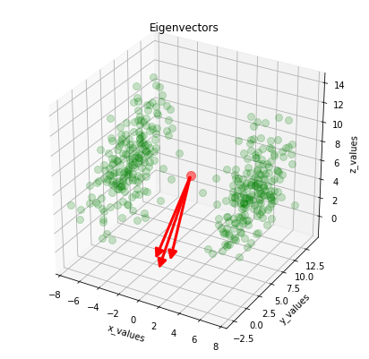

```python
%pylab inline

from matplotlib import pyplot as plt
from mpl_toolkits.mplot3d import Axes3D
from mpl_toolkits.mplot3d import proj3d
from matplotlib.patches import FancyArrowPatch


class Arrow3D(FancyArrowPatch):
    def __init__(self, xs, ys, zs, *args, **kwargs):
        FancyArrowPatch.__init__(self, (0,0), (0,0), *args, **kwargs)
        self._verts3d = xs, ys, zs

    def draw(self, renderer):
        xs3d, ys3d, zs3d = self._verts3d
        xs, ys, zs = proj3d.proj_transform(xs3d, ys3d, zs3d, renderer.M)
        self.set_positions((xs[0],ys[0]),(xs[1],ys[1]))
        FancyArrowPatch.draw(self, renderer)

fig = plt.figure(figsize=(7,7))
ax = fig.add_subplot(111, projection='3d')

ax.plot(all_samples[0,:], all_samples[1,:], all_samples[2,:], 'o', markersize=8, color='green', alpha=0.2)
ax.plot([mean_x], [mean_y], [mean_z], 'o', markersize=10, color='red', alpha=0.5)
for v in eig_vec_sc.T:
    a = Arrow3D([mean_x, v[0]], [mean_y, v[1]], [mean_z, v[2]], mutation_scale=20, lw=3, arrowstyle="-|>", color="r")
    ax.add_artist(a)
ax.set_xlabel('x_values')
ax.set_ylabel('y_values')
ax.set_zlabel('z_values')

plt.title('Eigenvectors')

plt.show()
```

# Step 6.1. Sorting the eigenvectors by decreasing eigenvalues

```python
for ev in eig_vec_sc:
    numpy.testing.assert_array_almost_equal(1.0, np.linalg.norm(ev))
    # instead of 'assert' because of rounding errors
```

```python
# Make a list of (eigenvalue, eigenvector) tuples
eig_pairs = [(np.abs(eig_val_sc[i]), eig_vec_sc[:,i]) for i in range(len(eig_val_sc))]

# Sort the (eigenvalue, eigenvector) tuples from high to low
eig_pairs.sort(key=lambda x: x[0], reverse=True)

# Visually confirm that the list is correctly sorted by decreasing eigenvalues
for i in eig_pairs:
    print(i[0])
```

```
14778.153297250476
3698.970976049397
3332.483626713129
```

# Step 6.2. Choosing k eigenvectors with the largest eigenvalues

Here we are reducing a 3-dimensional feature space to a 2-dimensional feature subspace, we are combining the two eigenvectors with the highest eigenvalues to construct our d x k-dimensional eigenvector matrix W

```python
matrix_w = np.hstack((eig_pairs[0][1].reshape(3,1), eig_pairs[1][1].reshape(3,1)))
print('Matrix W:\n', matrix_w)
```

```
Matrix W:
 [[ 0.99768566  0.06747468]
 [ 0.03490231 -0.40223228]
 [ 0.05835367 -0.91304784]]
```

# Step 7. Transforming the samples onto the new subspace

```python
transformed = matrix_w.T.dot(all_samples)
assert transformed.shape == (2,400)
```

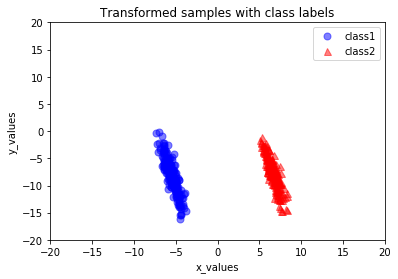

```python
plt.plot(transformed[0,0:200], transformed[1,0:200], 'o', markersize=7, color='blue', alpha=0.5, label='class1')
plt.plot(transformed[0,200:400], transformed[1,200:400], '^', markersize=7, color='red', alpha=0.5, label='class2')
plt.xlim([-20,20])
plt.ylim([-20,20])
plt.xlabel('x_values')
plt.ylabel('y_values')
plt.legend()
plt.title('Transformed samples with class labels')

plt.show()
```